# Kevin Gao - Assignment 1 (Data Selection and Initial Processing)

# Setup

We first install all the required packages if necessary. On my environment, `rlang` was not up-to-date so I had to update it manually, but for clearity sake, the output and command for updating `rlang` are not included here.

```r
if (!requireNamespace("BiocManager", quietly = TRUE))
  install.packages("BiocManager")

if (!requireNamespace("GEOmetadb", quietly = TRUE))
  BiocManager::install("GEOmetadb")

if (!requireNamespace("GEOquery", quietly = TRUE))
  BiocManager::install("GEOquery")

if (!requireNamespace("edgeR", quietly = TRUE))
  BiocManager::install("edgeR")

if (!requireNamespace("DESeq2", quietly = TRUE))
  BiocManager::install("DESeq2")

if (!requireNamespace("biomaRt", quietly = TRUE))
  BiocManager::install("biomaRt")

if (!requireNamespace("RSQLite", quietly = TRUE))
  install.packages("RSQLite")

if (!requireNamespace("pander", quietly = TRUE))
  install.packages("pander")

library("RSQLite")
library("knitr")
```

# GEOmetadb

Load GEOmetadb database file.

```r
if (!file.exists("GEOmetadb.sqlite"))
  GEOmetadb::getSQLiteFile()
con <- dbConnect(SQLite(), "GEOmetadb.sqlite")
```

List tables and information

```r
geoTables <- dbListTables(con)
geoTables
```

```
 [1] "gds"               "gds_subset"        "geoConvert"        "geodb_column_desc" "gpl"               "gse"               "gse_gpl"           "gse_gsm"
 [9] "gsm"               "metaInfo"          "sMatrix"
```

Build query

```r
# function for building an SQL query for GEOmetadb
buildQuery <- function(platformKeyword, technologyKeyword, organism, submissionDate, titleKeywords, suppFile) {
  gseTitleKeywords <- paste(lapply(titleKeywords, function(x) sprintf("gse.title LIKE '%%%s%%'", x)))
  gseTitleKeywords <- paste("(", paste(gseTitleKeywords, collapse = " OR "), ")")

  sel <- "SELECT DISTINCT gse.title, gse.gse, gpl.title, gse.submission_date, gse.supplementary_file"
  from <- "FROM gse JOIN gse_gpl ON gse_gpl.gse=gse.gse JOIN gpl ON gse_gpl.gpl=gpl.gpl"
  techCondition <- sprintf("WHERE gpl.title LIKE '%%%s%%' AND gpl.technology LIKE '%%%s%%' AND", platformKeyword, technologyKeyword)
  organismConstraint <- sprintf("gpl.organism LIKE '%%%s%%' AND", organism)
  dateConstraint <- sprintf("gse.submission_date > '%s' AND", submissionDate)
  titleConstraints <- gseTitleKeywords
  suppFileConstraint <- sprintf("AND gse.supplementary_file LIKE '%%%s%%.txt%%'", tolower(suppFile))
  sorting <- "ORDER BY gse.submission_date DESC"
  sql <- paste(sel, from, techCondition, organismConstraint, dateConstraint, titleConstraints, suppFileConstraint, sorting, sep = " ")
  return(sql)
}
```

Query GEOmetadb

```r
gplTitleKeyword <- "HiSeq"
gplTechKeyword <- "high-throughput sequencing"
gplOrganismKeyword <- "Homo sapiens"
gseDateConstraint <- '2017-01-01'
gseTitleKeywords <- c("SARS-CoV-2", "BRCA1", "Cdk", "CKI", "MAPK", "caspase", "kinase")
gseSuppfileKeyword <- "count"

result <- dbGetQuery(con, buildQuery(gplTitleKeyword, gplTechKeyword, gplOrganismKeyword, gseDateConstraint, gseTitleKeywords, gseSuppfileKeyword))
```

Let’s take a look at the size of the query result.

```r
dim(result)
```

```
[1] 25  5
```

# Selecting Dataset

We selected the dataset GSE168797, *Cannabidiol Inhibits SARS-CoV-2 Replication through Induction of the Host ER Stress and Innate Immune Responses*. I found this study particularly interesting because the result of this study was mentioned in numerous news stories claiming “weed cures COVID”. I would like to further investigate the data set accompanying the study and attempt to reproduce their results.

Fetch the supplementary files

```r
GEOquery::getGEOSuppFiles("GSE168797")
```

|  | size | isdir | mode | mtime | ctime | atime | uid | gid | uname | grname |
| --- | --- | --- | --- | --- | --- | --- | --- | --- | --- | --- |
| /home/rstudio/projects/school/bcb420/GSE168797/GSE168797_CBDV_raw_counts.txt.gz | 681679 | FALSE | 644 | 2022-02-23 00:17:49 | 2022-02-23 00:17:49 | 2022-02-22 01:05:00 | 1000 | 1000 | rstudio | rstudio |
| /home/rstudio/projects/school/bcb420/GSE168797/GSE168797_Raw_gene_counts_matrix.txt.gz | 759839 | FALSE | 644 | 2022-02-23 00:17:50 | 2022-02-23 00:17:50 | 2022-02-23 00:17:49 | 1000 | 1000 | rstudio | rstudio |

```r
# unzip the supplementary files
GEOquery::gunzip("./GSE168797/GSE168797_Raw_gene_counts_matrix.txt.gz", overwrite = TRUE)
```

Open the raw count file

```r
filename <- "./GSE168797/GSE168797_Raw_gene_counts_matrix.txt"
rawCount <- read.delim(filename, header = TRUE, check.name = FALSE, row.names = NULL)
row.names(rawCount) <- rawCount[[1]]
colnames(rawCount)[1] <- "ensembl_version"
res <- pander::pander_return(head(rawCount[2:13]))
```

```r
structure(res, class = "knitr_kable")
```

Table continues below

|  | CBD_infect-1 | CBD_infect-2 | CBD_infect-3 |
| --- | --- | --- | --- |
| **ENSG00000000003.10** | 1797 | 1912 | 2055 |
| **ENSG00000000005.5** | 0 | 0 | 0 |
| **ENSG00000000419.8** | 2820 | 2834 | 3028 |
| **ENSG00000000457.9** | 615 | 518 | 526 |
| **ENSG00000000460.12** | 439 | 523 | 553 |
| **ENSG00000000938.8** | 9 | 3 | 7 |

Table continues below

|  | Veh_infect-1 | Veh_infect-2 | Veh_infect-3 |
| --- | --- | --- | --- |
| **ENSG00000000003.10** | 1210 | 1190 | 1139 |
| **ENSG00000000005.5** | 0 | 0 | 2 |
| **ENSG00000000419.8** | 1984 | 1985 | 1981 |
| **ENSG00000000457.9** | 819 | 777 | 845 |
| **ENSG00000000460.12** | 779 | 781 | 849 |
| **ENSG00000000938.8** | 37 | 29 | 42 |

Table continues below

|  | CBD_mock-1 | CBD_mock-2 | CBD_mock-3 |
| --- | --- | --- | --- |
| **ENSG00000000003.10** | 2363 | 2162 | 1972 |
| **ENSG00000000005.5** | 0 | 0 | 0 |
| **ENSG00000000419.8** | 2655 | 2857 | 2643 |
| **ENSG00000000457.9** | 459 | 490 | 492 |
| **ENSG00000000460.12** | 672 | 640 | 526 |
| **ENSG00000000938.8** | 4 | 2 | 12 |

|  | Veh_mock-1 | Veh_mock-2 | Veh_mock-3 |
| --- | --- | --- | --- |
| **ENSG00000000003.10** | 2829 | 2854 | 2668 |
| **ENSG00000000005.5** | 0 | 0 | 0 |
| **ENSG00000000419.8** | 2545 | 2674 | 2486 |
| **ENSG00000000457.9** | 529 | 534 | 507 |
| **ENSG00000000460.12** | 1053 | 1102 | 1084 |
| **ENSG00000000938.8** | 0 | 0 | 0 |

```r
dim(rawCount)
```

```
[1] 57832    13
```

```r
summarized_gene_counts <- sort(table(rawCount$ensembl), decreasing = TRUE)
kable(summarized_gene_counts[1:3])
```

| Var1 | Freq |
| --- | --- |
| ENSG00000000003.10 | 1 |
| ENSG00000000005.5 | 1 |
| ENSG00000000419.8 | 1 |

The result tells us that there is no duplicate gene names (at least before identifier mapping).

# Define the Groups

```r
samples <- data.frame(lapply(colnames(rawCount)[2:13], function(x) {
  splt = unlist(strsplit(x, split = "_"))
  c(splt[1], unlist(strsplit(splt[2], split = "-"))[c(1,2)])
}))
rownames(samples) <- c("cbd_treatment", "infected", "patient")
colnames(samples) <- colnames(rawCount)[2:13]
samples <- data.frame(t(samples))
```

## Removing Ensembl Gene ID Version Number

The Ensembl Gene ID in the original dataset contains a version number. Searching by Ensembl ID with version number does not seem to get a good coverage during identifier mapping, so we create a separate column for the Ensembl Gene ID without version number.

```r
ensembl_id <- unlist(lapply(rawCount$ensembl, FUN = function(x) { unlist(strsplit(x, split = "\\."))[1] } ))
rawCount$ensembl_id <- ensembl_id
row.names(rawCount) <- rawCount$ensembl_id
```

# Removing Low Counts

```r
cpms = edgeR::cpm(rawCount[,2:13])
rownames(cpms) <- rawCount[,1]

# 3 biological replicates
keep = rowSums(cpms > 1) >= 3
rawCount_filtered <- rawCount[keep,]
```

The dimension of the filtered dataset.

```r
dim(rawCount_filtered)
```

```
[1] 14646    14
```

# Normalization

We would like to normalize the dataset and remove any technical variations.

## Examine Sample Distribution

Plotting the sample distribution

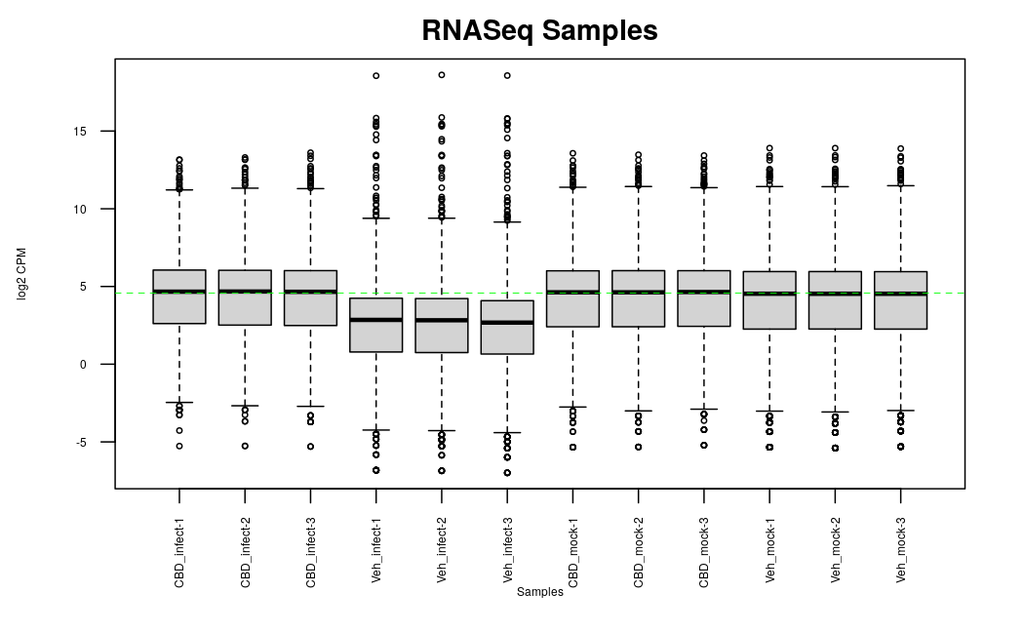

```r
data2plot <- log2(edgeR::cpm(rawCount_filtered[,2:13]))
boxplot(data2plot, xlab = "Samples", ylab = "log2 CPM", las = 2, cex = 0.5, cex.lab = 0.5, cex.axis = 0.5, main = "RNASeq Samples")
abline(h = median(apply(data2plot, 2, median)), col = "green", lwd = 0.6, lty = "dashed")
```

```r
counts_density <- apply(log2(edgeR::cpm(rawCount_filtered[,2:13])), 2, density)

xlim <- 0; ylim <- 0
for (i in 1:length(counts_density)) {
  xlim <- range(c(xlim, counts_density[[i]]$x));
  ylim <- range(c(ylim, counts_density[[i]]$y))
}
cols <- rainbow(length(counts_density))
ltys <- rep(1, length(counts_density))

plot(counts_density[[1]], xlim = xlim, ylim = ylim, type = "n", ylab = "Smoothing density of log2-CPM", main = "Sample Distribution (unnormalized)", cex.lab = 0.85)
for (i in 1:length(counts_density))
  lines(counts_density[[i]], col = cols[i], lty = ltys[i])
```

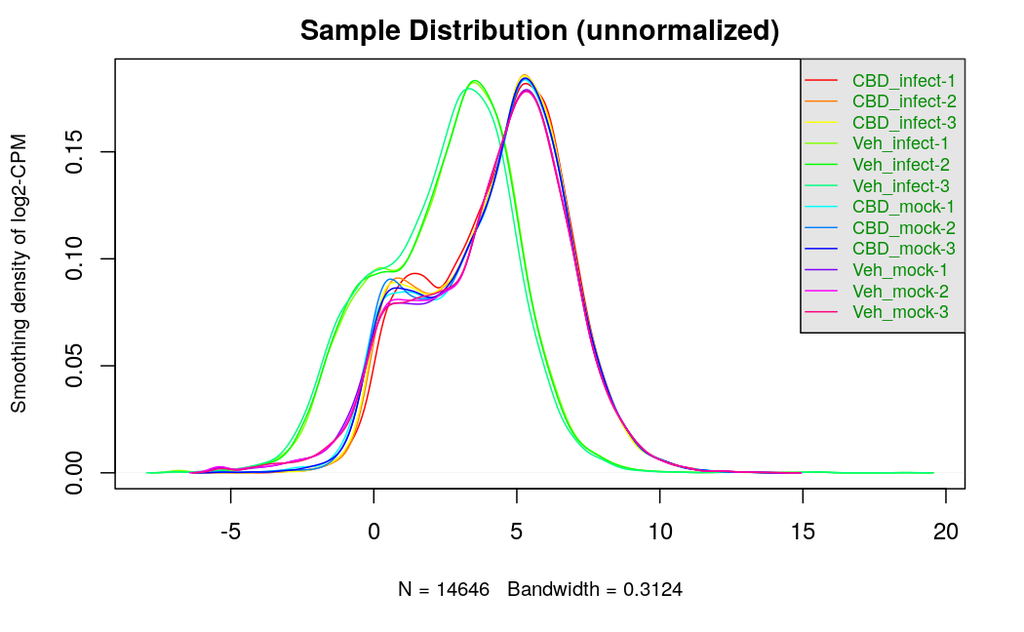

```r
legend("topright", colnames(data2plot), col=cols, lty=ltys, cex=0.75, border="blue", text.col = "green4", merge = TRUE, bg = "gray90")
```

As shown by the plot above, the sample mean of the set of samples infected with SARS-CoV-2 but without CBD treatment deviates significantly from rest of the samples. This suggests a possibility that the gene expression patterns is different in cells infected by SARS-CoV-2 without CBD treatment.

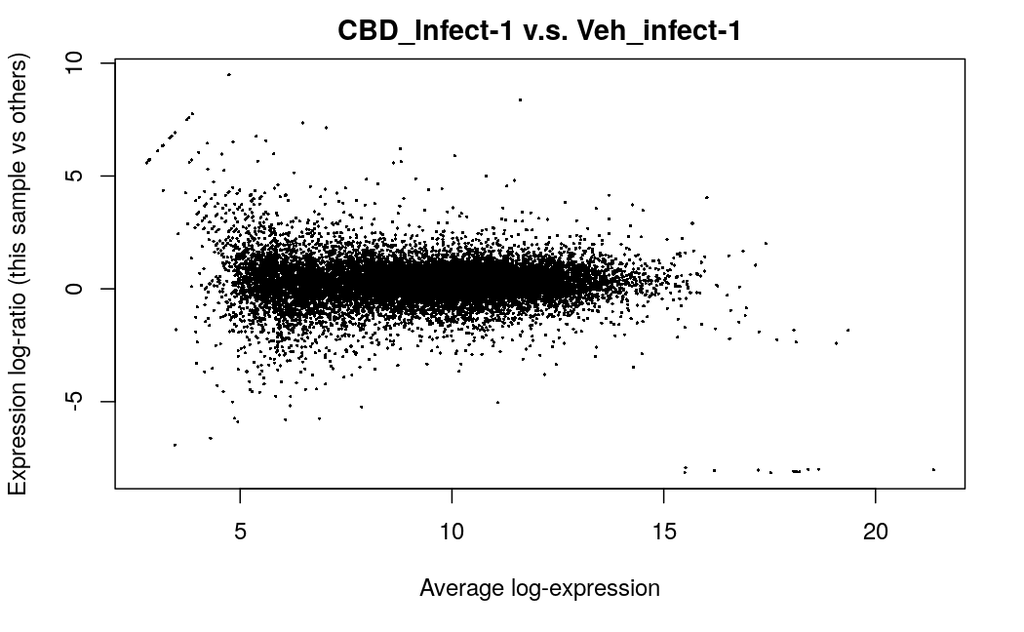

```r
limma::plotMA(log2(rawCount_filtered[,c(2,5)]), main = "CBD_Infect-1 v.s. Veh_infect-1")
```

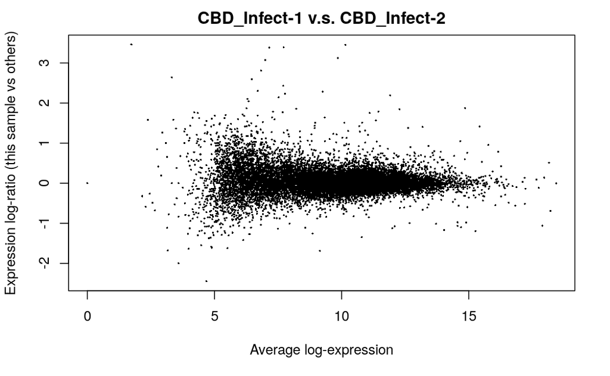

```r
limma::plotMA(log2(rawCount_filtered[,c(2,3)]), main = "CBD_Infect-1 v.s. CBD_Infect-2")
```

## Apply TMM Normalization

Since the sample distribution appears to be relatively normal (in terms of the shape of the distribution), we can use TMM normalization. Recall that the assumptions for TMM normalization are: - Differentially expressed genes and non-differentially expressed genes behave the same and technical variations affect them the same way; - The data is roughly balanced.

```r
filtered_data_mat <- as.matrix(rawCount_filtered[,2:13])
rownames(filtered_data_mat) <- rawCount_filtered$ensembl_id
d = edgeR::DGEList(counts = filtered_data_mat, group = samples$cbd_treatment)

d = edgeR::calcNormFactors(d)
normalized_counts <- edgeR::cpm(d)
```

Plot the normalized data

```r
counts_density_normalized <- apply(log2(normalized_counts), 2, density)

xlim <- 0; ylim <- 0
for (i in 1:length(counts_density_normalized)) {
  xlim <- range(c(xlim, counts_density_normalized[[i]]$x));
  ylim <- range(c(ylim, counts_density_normalized[[i]]$y))
}
cols <- rainbow(length(counts_density_normalized))
ltys <- rep(1, length(counts_density_normalized))

plot(counts_density_normalized[[1]], xlim = xlim, ylim = ylim, type = "n", ylab = "Smoothing density of log2-CPM", main = "Sample Distribution (normalized)", cex.lab = 0.85)
for (i in 1:length(counts_density_normalized))
  lines(counts_density_normalized[[i]], col = cols[i], lty = ltys[i])
```

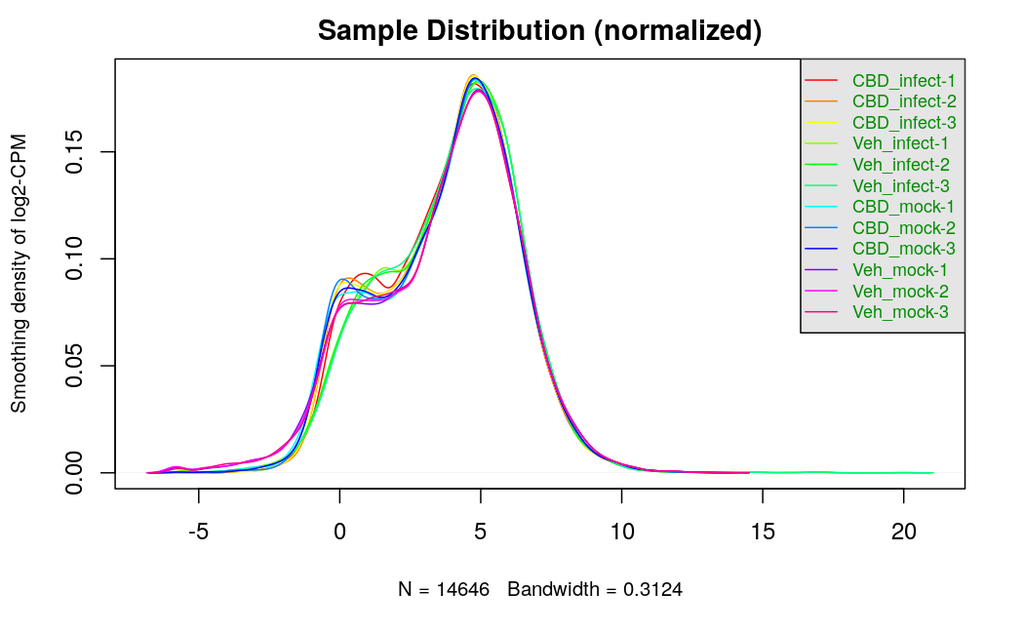

```r
legend("topright", colnames(data2plot), col=cols, lty=ltys, cex=0.75, border="blue", text.col = "green4", merge = TRUE, bg = "gray90")
```

Normalization corrects the large deviation of the means of untreated groups (green lines) from the groups treated with CBD, while still preserving some of the characteristics of the original sample distribution (e.g. the small bump at the left tail of the distribution).

Question: Could it be better to use a bimodal distribution because of the intial bump?

Replot the unnormalized version for comparison

```r
plot(counts_density[[1]], xlim = xlim, ylim = ylim, type = "n", ylab = "Smoothing density of log2-CPM", main = "Sample Distribution (unnormalized)", cex.lab = 0.85)
for (i in 1:length(counts_density))
  lines(counts_density[[i]], col = cols[i], lty = ltys[i])
```

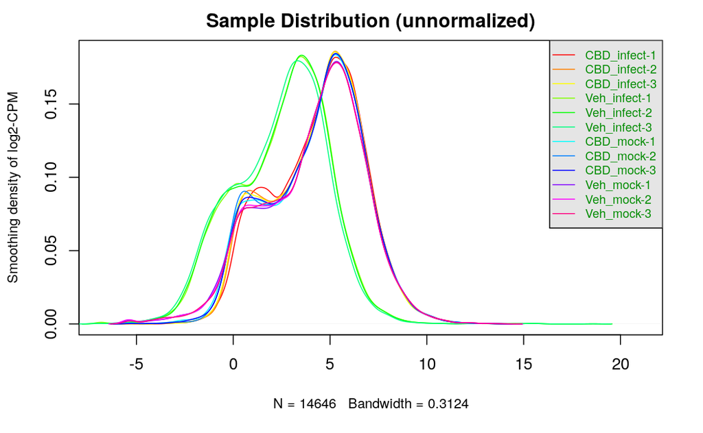

```r
legend("topright", colnames(data2plot), col=cols, lty=ltys, cex=0.75, border="blue", text.col = "green4", merge = TRUE, bg = "gray90")
```

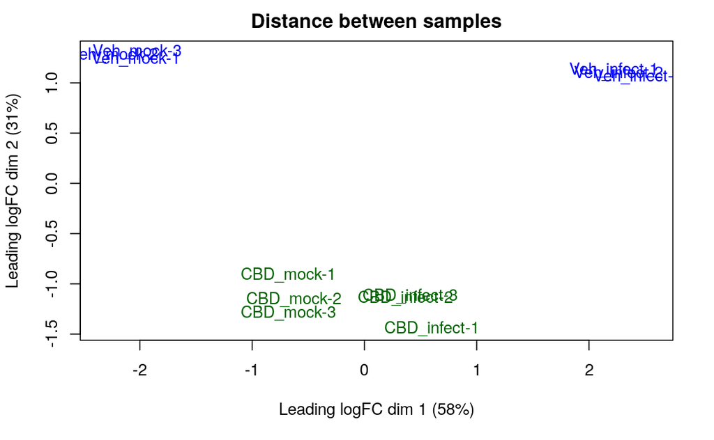

```r
limma::plotMDS(log2(normalized_counts), labels=rownames(samples), col = c("darkgreen","blue")[factor(samples$cbd_treatment)], main = "Distance between samples")
```

We also got a good separation of groups after normalization.

# Identifier Mapping

Since the original dataset included the Ensembl IDs of the genes, we can use Ensembl BioMart to do the identifier mapping and obtain the HUGO gene symbol.

```r
ensembl <- biomaRt::useMart("ensembl")
ensembl <- biomaRt::useDataset("hsapiens_gene_ensembl", mart=ensembl)
# since it takes some time to convert the identifiers, we would like to keep a local copy of the conversion file
conversion_stash <- "id_conversion.rds"
if (file.exists(conversion_stash)) {
  id_conversion <- readRDS(conversion_stash)
} else {
  # I noticed that `ensembl_transcript_id_version` does not have a good coverage, so I stripped the version number
  # and used the gene_id instead
  id_conversion <- biomaRt::getBM(attributes = c("ensembl_gene_id", "hgnc_symbol"),
                                  filters = c("ensembl_gene_id"),
                                  values = ensembl_id,
                                  mart = ensembl)
  saveRDS(id_conversion, conversion_stash)
}
```

[output not shown]

```r
nrow(normalized_counts) - length(which(ensembl_id %in% id_conversion$ensembl_gene_id))
```

```
[1] -37442
```

```r
normalized_counts_annot <- merge(id_conversion, normalized_counts,
                                 by.x = 1, by.y = 0, all.y=TRUE)

ensembl_id_missing_gene <- normalized_counts_annot$ensembl_gene_id[
  which(is.na(normalized_counts_annot$hgnc_symbol))]
length(ensembl_id_missing_gene)
```

```
[1] 350
```

We also have genes that did not get mapped to a name but has the empty string instead of NA as the identifier. We need to find those genes as well.

```r
ensembl_id_missing_gene <- c(ensembl_id_missing_gene, normalized_counts_annot$ensembl_gene_id[
                              which(normalized_counts_annot$hgnc_symbol == "")])
length(ensembl_id_missing_gene)
```

```
[1] 940
```

There is one duplicate identifier belonging to a pseudogene.

```r
dup_id <- which(duplicated(normalized_counts_annot$hgnc_symbol)==TRUE)
normalized_counts_annot[dup_id,]
```

|  | ensembl_gene_id | hgnc_symbol | CBD_infect-1 | CBD_infect-2 | CBD_infect-3 | Veh_infect-1 | Veh_infect-2 | Veh_infect-3 | CBD_mock-1 | CBD_mock-2 | CBD_mock-3 | Veh_mock-1 | Veh_mock-2 | Veh_mock-3 |
| --- | --- | --- | --- | --- | --- | --- | --- | --- | --- | --- | --- | --- | --- | --- |
| 14560 | ENSG00000272655 | POLR2J4 | 1.40186 | 1.90074 | 1.847286 | 2.416075 | 2.454559 | 1.890313 | 1.98612 | 1.889105 | 2.177168 | 3.611087 | 2.921413 | 3.150388 |

```r
normalized_counts_annot <- normalized_counts_annot[!(normalized_counts_annot$ensembl_gene_id %in% ensembl_id_missing_gene),]
normalized_counts_annot <- normalized_counts_annot[-dup_id,]
```

Set the row names to HUGO symbols.

```r
row.names(normalized_counts_annot) <- normalized_counts_annot$hgnc_symbol
```

The final dataset:

```r
head(normalized_counts_annot[3:14])
```

|  | CBD_infect-1 | CBD_infect-2 | CBD_infect-3 | Veh_infect-1 | Veh_infect-2 | Veh_infect-3 | CBD_mock-1 | CBD_mock-2 | CBD_mock-3 | Veh_mock-1 | Veh_mock-2 | Veh_mock-3 |
| --- | --- | --- | --- | --- | --- | --- | --- | --- | --- | --- | --- | --- |
| TSPAN6 | 31.887883 | 34.611576 | 36.856052 | 27.57973 | 26.79748 | 25.94055 | 41.532765 | 38.530620 | 37.661184 | 52.388541 | 50.839708 | 50.633944 |
| DPM1 | 50.041085 | 51.301886 | 54.306630 | 45.22163 | 44.70000 | 45.11698 | 46.665041 | 50.916735 | 50.475917 | 47.129316 | 47.633279 | 47.179904 |
| SCYL3 | 10.913215 | 9.376986 | 9.433715 | 18.66760 | 17.49718 | 19.24475 | 8.067516 | 8.732657 | 9.396198 | 9.796231 | 9.512405 | 9.621968 |
| C1orf112 | 7.790084 | 9.467497 | 9.917955 | 17.75587 | 17.58725 | 19.33585 | 11.811265 | 11.405919 | 10.045529 | 19.499870 | 19.630469 | 20.572412 |
| CFH | 17.425654 | 19.731495 | 18.365254 | 29.69949 | 23.19446 | 29.03793 | 19.175729 | 18.213827 | 15.832212 | 42.610828 | 45.246271 | 38.791522 |
| FUCA2 | 47.893932 | 54.397378 | 54.772936 | 33.46036 | 31.79668 | 31.58872 | 58.247814 | 54.784054 | 57.465772 | 64.221795 | 56.486585 | 56.213546 |

# Interpretation

# References

- Chen Y, Lun ATL, Smyth GK (2016). From reads to genes to pathways: differential expression analysis of RNA-Seq experiments using Rsubread and the edgeR quasi-likelihood pipeline. F1000Research 5, 1438
- Davis, S. and Meltzer, P. S. GEOquery: a bridge between the Gene Expression Omnibus (GEO) and BioConductor. Bioinformatics, 2007, 14, 1846-1847
- Evans, C., Hardin, J., & Stoebel, D. M. (2018). Selecting between-sample RNA-Seq normalization methods from the perspective of their assumptions. Briefings in bioinformatics, 19(5), 776–792. https://doi.org/10.1093/bib/bbx008
- Durinck, S., Spellman, P. T., Birney, E., & Huber, W. (2009). Mapping identifiers for the integration of genomic datasets with the R/Bioconductor package biomaRt. Nature - protocols, 4(8), 1184–1191. https://doi.org/10.1038/nprot.2009.97
- Martin Morgan (2021). BiocManager: Access the Bioconductor Project Package Repository. R package version 1.30.16. https://CRAN.R-project.org/package=BiocManager
- McCarthy DJ, Chen Y and Smyth GK (2012). Differential expression analysis of multifactor RNA-Seq experiments with respect to biological variation. Nucleic Acids Research 40, 4288-4297
- Nguyen, L. C., Yang, D., Nicolaescu, V., Best, T. J., Ohtsuki, T., Chen, S.-N., Friesen, J. B., Drayman, N., Mohamed, A., Dann, C., Silva, D., Gula, H., Jones, K. A., Millis, J. M., Dickinson, B. C., Tay, S., Oakes, S. A., Pauli, G. F., Meltzer, D. O., … Rosner, M. R. (2021). Cannabidiol inhibits SARS-COV-2 replication and promotes the host innate immune response. Science Advances. https://www.science.org/doi/abs/10.1126/sciadv.abi6110
- Robinson MD, McCarthy DJ and Smyth GK (2010). edgeR: a Bioconductor package for differential expression analysis of digital gene expression data. Bioinformatics 26, 139-140
- Zhu Y, Davis S, Stephens R, Meltzer PS, Chen Y. GEOmetadb: powerful alternative search engine for the Gene Expression Omnibus. Bioinformatics. 2008 Dec 1;24(23):2798-800. doi: 10.1093/bioinformatics/btn520. Epub 2008 Oct 7. PubMed PMID: 18842599; PubMed Central PMCID: PMC2639278.